# Omitted Variable Bias

### **NOTES ON STATISTICS, PROBABILITY and MATHEMATICS**

### Omitted Variable Bias (OVB):

After [this post](http://stats.stackexchange.com/q/142693/67822).

by using this function:

```
correlatedValue = function(x, r){
  r2 = r**2
  ve = 1 - r2
  SD = sqrt(ve)
  e  = rnorm(length(x), mean = 0, sd = SD)
  y  = r * x + e
}
```

-thank you, @gung for this post: http://stats.stackexchange.com/questions/38856/how-to-generate-correlated-random-numbers-given-means-variances-and-degree-of

And the following function, which generates four variables (*x1*, *x2*, *x3* and *x4*) as well as noise (*eps*). *x1* and *x3* are sample from normal distributions; *x2* is extracted from a uniform; and *x4* from a Poisson.

```
variables <- function(){
x <- rnorm(1000)
x1 <- 50 + 15 * x
x3 <- 28 + 11 * correlatedValue(x = x, r = 0.6)
x2 <- runif(1000, 0, 100)
x4 <- rpois(1000,50)
eps <- rnorm(1000,5, 7)
y = 7.2 + 2.3 * x1 + 0.001 * x2 + 1.5 * x3 + 0.013 * x4 + eps
dat <- as.data.frame(cbind(y, x1, x2, x3, x4))
c <- as.numeric(coef(lm(y ~ x2 + x3 + x4, dat))[3])
d <- as.numeric(coef(lm(y ~ x1 + x2 + x3 + x4, dat))[4])
c(c,d)
}
```

*x1* and *x3* are highly influential on *y* and are correlated with each other, setting the values up to observe *OVB*. *x2* and *x4* are less influential.

Here is the plotting of *y* against *x1*, *x2*, *x3* and *x4*, and *x1* over *x3* with added regression lines:

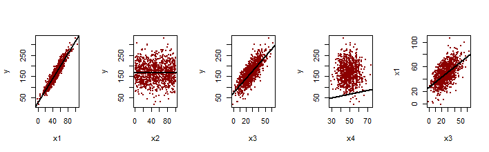

```
             y           x1           x2         x3          x4
y   1.00000000  0.944410945  0.014421682 0.77571067 -0.01463981
x1  0.94441094  1.000000000 -0.001726526 0.56504020 -0.03562991
x2  0.01442168 -0.001726526  1.000000000 0.03537959  0.02253922
x3  0.77571067  0.565040198  0.035379590 1.00000000  0.02573827
x4 -0.01463981 -0.035629906  0.022539218 0.02573827  1.00000000
```

Predictably, the regression including all variables shows similar coefficients to the initial equation:

```
coef(lm(y~.,dat))[2:5]
         x1          x2          x3          x4
2.253353226 0.004899445 1.547915198 0.017710038
```

Wrapping up, a quick simulation is carried out to obtain the mean of the *x3* coefficient in 1,000 simulations *WITHOUT* including *x1* (“coef_x3”) and then *WITH* *x1* (“coef_x3_full”):

```
coef_x3 <- NULL
coef_x3_full <- NULL
for (i in 1:1000){
  coef_x3[i] = variables()[1]
  coef_x3_full[i] = variables()[2]
}
mean(coef_x3)
mean(coef_x3_full)
```

obtaining a coefficient for *x3* of **3.383** when *x1* is excluded versus a coefficient for *x3* of **1.502** when included. So when *x1* is included we have an unbiased estimation of the true *x3* coefficient (*1.5*), whereas the estimation is biased when we exclude *x1*.

[Home Page](http://rinterested.github.io/statistics/index.html)

**NOTE: These are tentative notes on different topics for personal use - expect mistakes and misunderstandings.**